# 서울특별시 365 열린어린이집 입지분석

2018312757 송승현, 2017310921 심현구, 2020312491 천예원

# 💻 **주제 선정 배경**

#### 저출생과 가족 구성원의 다양화로, 사회 복지 차원에서의 아동 보육 서비스의 중요성이 증가하고 있다. 긴급한 상황에서 자녀를 믿고 맡길 수 있는 사회적 안전망의 존재야말로 어쩌면 아동 보육 분야의 복지에 있어 가장 필요한 사업 중 하나이다. 본 분석은 이러한 문제 의식에서 출발하여 서울특별시의 긴급 보육 시설, 그 중에서도 “365 열린 어린이집”의 최적 입지를 탐색하고, 그 타당성을 점검한다.

### 👪 **서울특별시 ‘엄마 아빠 행복 프로젝트’**

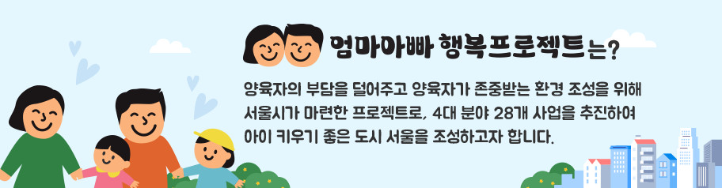

▲ 클릭하여 상세페이지로 이동

#### “엄마 아빠 행복프로젝트”는 서울특별시가 자녀를 키우는 부모들의 육아 부담을 덜어주고, 자녀를 양육하기 좋은 서울특별시를 만들기 위해 지난 2022년 8월 발표한 정책으로, 2023년 지금까지도 다양한 사업을 적극 지원하고 있다. “안심돌봄”, “편한외출”, “건강힐링” 그리고 “일/생활균형”의 4대 양육 분야를 아우르는 양육 지원 사업을 적극적으로 지원함으로써 현실적인 육아 부담을 줄이고 ’아이 키우기 좋은 서울’을 만드는 것이 본 사업의 목표이다. 상술한 4대 양육 분야의 사업 내용은 아래와 같다.

| 안심돌봄 | 편한외출 | 건강힐링 | 일생활균형 |
| --- | --- | --- | --- |
| 육아조력자 돌봄수당 바우처 | 서울엄마아빠VIP존 조성 | 힐링타임 문화 프로젝트 | 엄마아빠 육아휴직장려금 |
| 틈새보육 SOS 서비스 | 가족화장실 조성 | 출산맘 몸·마음 토탈케어 | 임산부·맞벌이·다자녀 가정 가사서비스 지원 |
| 돌봄까지 책임지는 서울형 키즈카페 확대 | 가족우선주차장 조성 | 서울아이 발달지원 센터 | 아이 삼시세끼 틈새 지원 |
| 공보육·틈새보육 시설 확층 | 서울엄마아빠택시 운영 | 맞춤형 양육코칭 프로그램 지원 | 경력보유여성 취업 3종세트 |

### 👶 **틈새 보육 서비스 현황**

#### 상술한 바와 같이 서울특별시는 틈새보육 해결을 위해 다양한 사업을 시도하고 있다. “틈새보육 SOS 서비스”는 거점형 야간보육시설, 365 열린 어린이집, 휴일보육 등 아이의 임시 보육을 지원하는 사업에 초점을 두고 있다. 그러나 이에 보육업계 전문가들과 학부모들은 보육의 질 향상을 위하여 *“부분적인 해결책보다 여러 문제를 한번에 해결할 수 있는 방법을 찾아야 한다”*고 지적하고 있다. 바로 365 열린 어린이집의 확대이다. 365일, 24시간, 주중/주말 언제나 운영되는 365 열린 어린이집의 절대적인 수를 늘리면 야간어린이집이나 주말어린이집을 따로 운영할 필요가 없어지기 때문이다.

### 🏠 **365어린이집이란?**

#### 365열린어린이집은 365일 24시간 일시보육을 제공하는 보육시설이다. 가정에서 필요한 시간만큼 이용할 수 있다는 점에서 시간제 보육과 유사하다. 이용대상은 서울시에 주소를 둔 6개월 이상 미취학 영유아이며, 이용요금은 시간당 3000원이다. 기존에 운영 중인 어린이집이 서울시의 선발을 거쳐 365어린이집으로 선정되면 야간, 주말에도 운영하며 보육 서비스를 제공해 일반적이지 않은 근로형태를 가진 부모가 아이를 맡길 수 있는 보육시설이 확보된다. 서울특별시는 “*다양해진 근로 형태를 반영해 휴일과 야간에도 이용할 수 있는 틈새 보육 서비스를 권역별로 균형 있게 확대해 나가겠다*”고 발표했다.

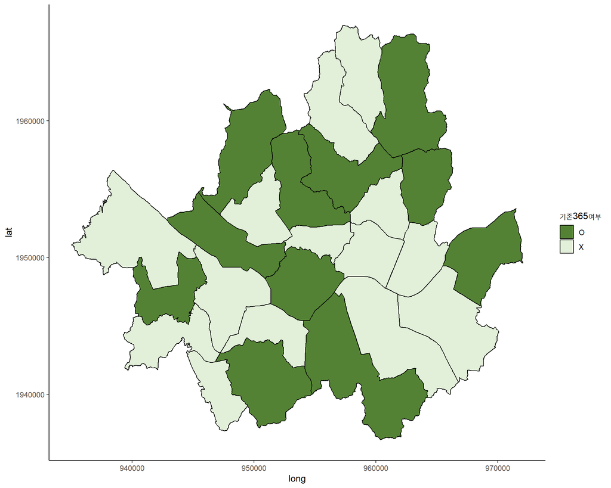

▲ 2023 상반기 서울특별시 365 열린어린이집 개소 현황 (지도시각화)

| 연번 | 권역 | 자치구 | 유형 | 시설명 | 개시연월 |
| --- | --- | --- | --- | --- | --- |
| 1 | 도심권 | 종로구 | 국공립 | 조은어린이집 | 2022.03 |
| 2 | 도심권 | 용산구 | 국공립 | 동빙고어린이집 | 2022.09 |
| 3 | 동남권 | 강동구 | 국공립 | 구립꿈사랑어린이집 | 2022.10 |
| 4 | 동남권 | 서초구 | 민간 | 파란나라어린이집 | 2023.03 |
| 5 | 동북권 | 중랑구 | 국공립 | 햇살아래보듬이나눔어린이집 | 2017.03 |
| 6 | 동북권 | 성북구 | 민간 | 성신어린이집 | 2022.03 |
| 7 | 동북권 | 노원구 | 국공립 | 상계5동보듬이나눔어린이집 | 2011.10 |
| 8 | 서남권 | 양천구 | 직장 | 양천구직장어린이집 | 2011.09 |
| 9 | 서남권 | 관악구 | 국공립 | 성현햇살어린이집 | 2011.09 |
| 10 | 서북권 | 마포구 | 국공립 | 연봉어린이집 | 2021.11 |
| 11 | 서북권 | 은평구 | 민간 | 성모자애어린이집 | 2023.03 |

▲ 2023 상반기 서울특별시 365 열린어린이집 개소 현황 (표)

#### 2023년 10월 기준 서울특별시 25개 자치구 중 365 열린 어린이집이 운영되고 있는 구는 11개다. 보육업계 전문가들과 학부모들의 지적에도 불구하고 인구 58만의 강서구, 인구 54만의 강남구, 인구 67만명의 송파구에는 365 열린 어린이집이 단 1개소도 설치되어 있지 않은 상황이다. 실제 전년 대비 365 열린 어린이집의 이용실적이 125% 증가했음을 고려했을 때 365 열린 어린이집의 개수는 턱 없이 부족한 실정이다. 이에 서울특별시는 2024년까지 자치구별 365 열린 어린이집의 1개소 이상 개원을 목표로 하고 있다.

# 🎯 **분석 목표**

#### 서울특별시의 365 열린 어린이집 추가 개소 가능성을 확인하였다. 본 분석은 서울특별시 365 열린 어린이집의 추가 입지분석을 통하여 (1) 다양한 틈새 보육 서비스를 포괄하는 통일된 지침을 만들어 긴급 돌봄 서비스에 대한 보완책을 제시하며, (2) 자치구별 긴급 돌봄 수요를 반영해 365 열린 어린이집을 선정하여 지역별로 균형있는 돌봄 서비스를 제공하고자 한다. 이를 통해 서울특별시에서 진행하는 “엄마 아빠 행복 프로젝트” 사업인 틈새 보육 서비스의 효과적인 진행을 도모하는 것이 궁극적인 목표다.

# 📜 **수집 데이터 목록**

#### 데이터셋 이름 클릭 시 출처로 이동

- [[서울 열린데이터 광장] **서울시 어린이집 정보**](https://data.seoul.go.kr/dataList/OA-20300/S/1/datasetView.do)
  - 어린이집명, 주소, 보육실 면적, 보육교직원 수, 정원, 현원, 인가일자 등
  - 2022년 기준 데이터
- [[서울 열린데이터 광장] **365 어린이집 개소 현황**](https://data.seoul.go.kr/dataList/OA-21701/S/1/datasetView.do)
  - 어린이집명, 주소, 인가일자, 전체 정원, 보육서비스 정원 등
  - 2023년 기준 데이터
- [[서울 열린데이터 광장] **서울시 자치구별 저소득 한부모가족현황**](https://data.seoul.go.kr/dataList/437/S/2/datasetView.do)
  - 한부모가족지원법 수급자 가구수/가구원수, 국민기초생활법 수급자 가구수/가구원수
  - 2021년 기준 데이터
- [[지디에스컨설팅그룹] **행정동별 가구 특성정보와 소득정보**](https://www.bigdata-environment.kr/user/data_market/detail.do?id=8cee0160-2dff-11ea-9713-eb3e5186fb38)
  - 행정동명(+코드), 행정동별 가구 평균 소득
  - 2021년 기준 데이터
- [[서울 열린데이터 광장] **서울시 자치구별 보육교사 1인당 아동수 통계**](https://data.seoul.go.kr/dataList/10755/S/2/datasetView.do)
  - 자치구별 보육교사 1인당 아동수 (소수 둘째 자리에서 반올림)
  - 2022년 기준 데이터
- [[서울 열린데이터 광장] **서울시 자치구별 보육시설 통계**](https://data.seoul.go.kr/dataList/71/S/2/datasetView.do)
  - 자치구별 국공립, 사회복지법인, 법인·단체, 민간, 가정, 부모협동, 직장 어린이집 개수
  - 2022년 기준 데이터
- [[서울 열린데이터 광장] **서울시 자치구별 보육시설 이용 아동 비율 통계**](https://data.seoul.go.kr/dataList/10862/S/2/datasetView.do)
  - 자치구별 국공립, 사회복지법인, 법인·단체, 민간, 가정, 부모협동, 직장 어린이집 이용 아동 수
  - 2022년 기준 데이터
- [[서울 열린데이터 광장] **서울시 자치구별 어린이집 보유교직원 현황**](https://data.seoul.go.kr/dataList/OA-15455/S/1/datasetView.do)
  - 자치구별 원장 수(남/여), 보육교사 수(남/여), 간호사 수(남/여), 영양사 수(남/여), 특수교사 수(남/여) 등
  - 2022년 기준 데이터
- [**서울시 지하철역 좌표 데이터**](https://observablehq.com/@taekie/seoul_subway_station_coordinate)
  - 호선, 역이름, 역코드, 위도, 경도
- [[공공데이터포털] **보건복지부 평가인증 어린이집 정보 현황**](https://www.data.go.kr/data/15001277/fileData.do)
  - 평가인증을 받은 어린이집명, 어린이집유형, 주소, 정원, 현원
  - 2022년 기준 데이터
- [[서울 열린데이터 광장] **서울시 주민등록인구 (구별) 통계**](https://data.seoul.go.kr/dataList/419/S/2/datasetView.do)
  - 주민등록인구수를 자치구별로 제공하는 일반·보고통계
  - 2023년 기준 데이터

# 📎 **데이터 전처리 및 결합**

#### *코드청크는 숨김처리 하였음*.

#### 수집한 데이터셋을 로드한다.

#### 불필요하다고 판단되는 열(‘우편번호’, ‘상세주소’, ‘전화번호’, ‘팩스번호’, ‘홈페이지주소’, ‘데이터기준일자’, ‘데이터수집일’)을 제거한다.

#### 데이터 수집일 당시 **운영 중**인 어린이집만을 대상으로 한다. 운영 여부는 “운영현황” 열을 기준으로 ‘정상’ 또는 휴지 후 ’재개’인 값을 추출한다. “운영현황” 열을 제외하고 어린이집의 운영 여부와 관련한 열을 삭제한다.

#### **열별 결측치**를 확인한다.

- 어린이집 위치의 **좌표값이 결측치**인 관측치 모두 상위 기관(육아종합지원센터 등)에 포함된 하위 기관이며 교직원수, 현원 등 기본정보가 0으로 표기되어있음을 확인하여 제거한다.

```
## [1] "좌표값이 결측치인 어린이집: 112 개"
```

- 또한 정보가 잘못 입력되어 **북한이나 경기도 소재**로 기입된 어린이집을 두 곳(구립내일어린이집, 봄빛어린이집) 발견해 제거한다.
- **근속년수**의 결측치가 동시에 나타나는 패턴이 관측되기 때문에 근속년수별 인원의 평균으로 대체한다.

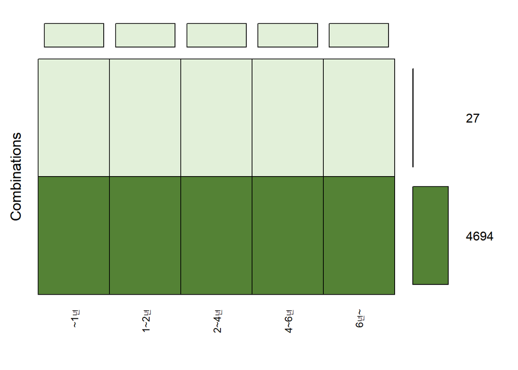

  ▲ “보육교사근속년수” 관련 변수 결측치 패턴
- **교직원현황**의 결측치 또한 동시에 나타나지만, 교직원의 형태에 따라 다르게 대체한다. 원장과 보육교사의 결측치는 1로, 나머지는 0으로 대체한다.

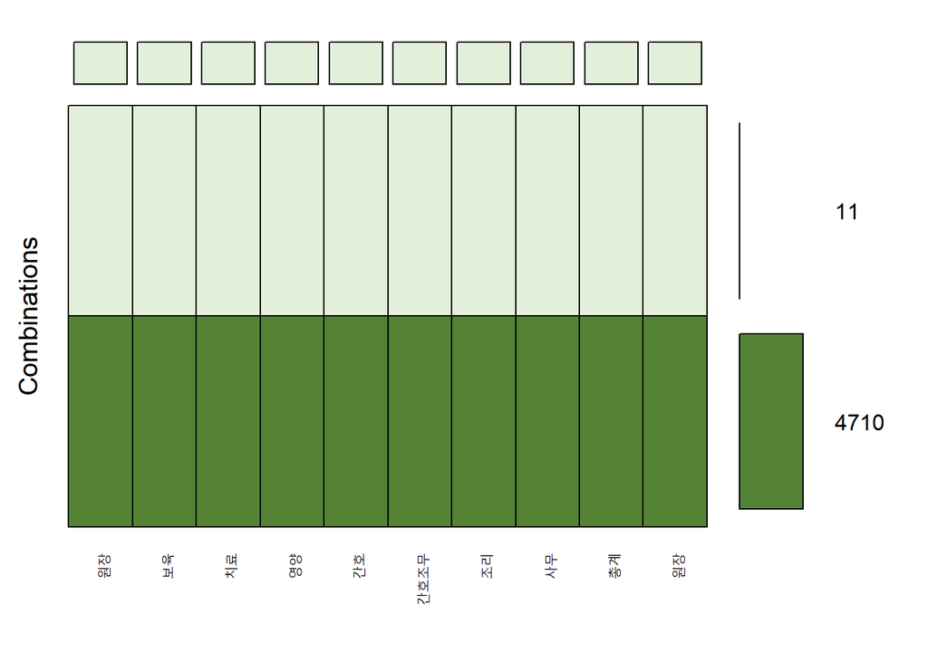

  ▲ “교직원현황” 관련 변수 결측치 패턴

#### 어린이집 정보 데이터셋에 **자치구별 전체 보육교사 수** 열을 추가한다.

#### 어린이집 정보 데이터셋에 **자치구별 보육교사 1인당 학생수** 열을 추가한다.

#### 어린이집 정보 데이터셋에 **자치구별 보육시설수** 열을 추가한다.

- 해당 유형의 어린이집이 0인 값이 “-”으로 입력되어 있어 0.0으로 바꾼다.

#### 어린이집 정보 데이터셋에 자치구별 보육시설 이용아동수와 이용비율 열을 추가한다.

- 어린이집 유형별 이용아동수와 이용비율이 0인 값이 “-”으로 입력되어 있어 0.0으로 바꾼다.

#### 어린이집 정보 데이터셋에 **자치구별 가구 평균소득** 열을 추가한다.

#### 어린이집 정보 데이터셋에 **자치구별 저소득 한부모가구** 열을 추가한다.

#### 어린이집 정보 데이터셋에 **365어린이집 여부** 열을 추가한다.

```
## [1] "서울특별시 소재 365어린이집: 11 개소"
```

- 어린이집명은 띄어쓰기의 차이나, “구립” 등 미세한 차이가 있기 때문에 어린이집 코드를 기준으로 결합한다.
- 서울특별시에는 총 11개의 365 열린 어린이집이 개소하였음을 확인하였다.

#### 각 어린이집과 **가장 가까운 지하철역의 거리**를 계산한 열을 추가한다.

```
## [1] "지하철역 좌표 결측치: 30 개"
```

- 좌표값이 결측치인 지하철역이 30개 존재하지만 경기도 소재 신설역으로 서울시 어린이집과의 거리와 무관하다고 판단하여 제거한다.
- 각 어린이집과 모든 지하철역 간의 거리(미터)를 계산한 후 가장 가까운 거리를 “지하철역최단거리”열로 추가한다.

#### 어린이집 정보 데이터셋에 **자치구별 거주인구** 열을 추가한다.

#### 어린이집 정보 데이터셋에 **평가인증여부** 열을 추가한다.

```
## [1] "평가인증받은 어린이집: 3157 개소"
```

- 어린이집명에 약간의 차이가 있지만 평가인증 데이터셋에는 어린이집코드가 제공되지 않았기 때문에 공백을 제거한 어린이집명을 기준으로 결합한다.
- 서울특별시에는 총 3157개의 어린이집이 평가인증을 받았음을 확인하였다.

#### 표준 데이터셋의 열 이름을 적절하게 수정한다.

|  | 시군구명 | 어린이집코드 | 어린이집명 | 어린이집유형 | 운영현황 | 보육실수 | 보육실면적 | 놀이터수 | CCTV총설치수 | 보육교직원수 | 정원 | 현원 | lat | lng | 통학차량운영여부 | 인가일자 | 제공서비스 | 반수만0세 | 반수만1세 | 반수만2세 | 반수만3세 | 반수만4세 | 반수만5세 | 반수영아혼합만02세 | 반수유아혼합만35세 | 반수특수장애 | 반수총계 | 아동수만0세 | 아동수만1세 | … |
| --- | --- | --- | --- | --- | --- | --- | --- | --- | --- | --- | --- | --- | --- | --- | --- | --- | --- | --- | --- | --- | --- | --- | --- | --- | --- | --- | --- | --- | --- | --- |
| 1 | 강남구 | 11680000399 | 키즈열매어린이집 | 가정 | 정상 | 3 | 56 | 0 | 4 | 7 | 20 | 15 | 37.4676444005455 | 127.092749362994 | 미운영 | 2012-10-18 | 일반 | 3 | 2 | 1 | 0 | 0 | 0 | 3 | 1 | 0 | 10 | 0 | 5 | … |
| 2 | 강남구 | 11680000498 | 쿠키즈(coukids) 어린이집 | 직장 | 정상 | 4 | 188 | 0 | 18 | 14 | 49 | 21 | 37.5038904224137 | 127.048167367398 | 미운영 | 2021-03-26 | 일반 | 0 | 2 | 3 | 1 | 0 | 0 | 0 | 1 | 0 | 7 | 0 | 9 | … |
| 3 | 강남구 | 11680000154 | 대청어린이집 | 국공립 | 정상 | 5 | 215 | 1 | 8 | 16 | 65 | 56 | 37.49087497 | 127.083511 | 미운영 | 1996-11-26 | 야간연장 | 2 | 2 | 2 | 1 | 0 | 0 | 0 | 1 | 0 | 8 | 6 | 10 | … |
| 4 | 강남구 | 11680000499 | 도토리소풍넥슨 대치어린이집 | 직장 | 정상 | 5 | 198 | 1 | 35 | 11 | 49 | 10 | 37.56647 | 126.977963 | 미운영 | 2021-03-30 | 일반 | 0 | 1 | 2 | 2 | 2 | 0 | 0 | 0 | 0 | 7 | 0 | 4 | … |
| 5 | 강남구 | 11680000144 | 대치어린이집 | 국공립 | 정상 | 7 | 259 | 2 | 24 | 26 | 107 | 92 | 37.5018721 | 127.0655398 | 미운영 | 1996-04-01 | 야간연장 | 4 | 4 | 3 | 1 | 1 | 1 | 0 | 0 | 0 | 14 | 9 | 20 | … |
| 6 | 강남구 | 11680000024 | 사과나무어린이집 | 민간 | 정상 | 7 | 234 | 1 | 12 | 15 | 88 | 57 | 37.51108922 | 127.0257611 | 운영 | 1996-09-26 | 일반 | 0 | 0 | 1 | 1 | 0 | 2 | 4 | 2 | 0 | 10 | 0 | 0 | … |
| 7 | 강남구 | 11680000054 | 나하나어린이집 | 가정 | 정상 | 3 | 92 | 4 | 4 | 5 | 20 | 8 | 37.4913658292944 | 127.088233663901 | 미운영 | 1999-07-22 | 야간연장 | 2 | 2 | 1 | 0 | 0 | 0 | 4 | 0 | 0 | 9 | 0 | 0 | … |
| 8 | 강남구 | 11680000380 | 지예슬어린이집 | 직장 | 정상 | 4 | 180 | 1 | 19 | 16 | 68 | 32 | 37.5033690408808 | 127.034612849865 | 미운영 | 2012-03-02 | 일반 | 0 | 4 | 2 | 0 | 0 | 2 | 0 | 3 | 0 | 11 | 0 | 8 | … |
| 9 | 강남구 | 11680000358 | 리엔어린이집 | 민간 | 정상 | 3 | 70 | 0 | 3 | 4 | 25 | 5 | 37.4643883571 | 127.104164884 | 미운영 | 2011-03-23 | 일반 | 0 | 1 | 1 | 0 | 0 | 0 | 8 | 1 | 0 | 11 | 0 | 0 | … |
| 10 | 강남구 | 11680000175 | 역삼가애어린이집 | 국공립 | 정상 | 10 | 455 | 3 | 16 | 20 | 138 | 95 | 37.49483065 | 127.0447335 | 미운영 | 1977-04-01 | 야간연장,시간제보육 | 2 | 2 | 4 | 2 | 1 | 2 | 0 | 0 | 0 | 13 | 6 | 10 | … |

[output cut: 90 more lines]

▲ 최종데이터셋 상위 100개 행 (표)

#### 각 어린이집의 정보를 Rshiny를 활용해 동적 대시보드로 시각화했다.(첨부된 App.R참고)

# 🔍 **EDA**

### 👩‍🎓 **자치구별 보육교사 1인당 학생수**

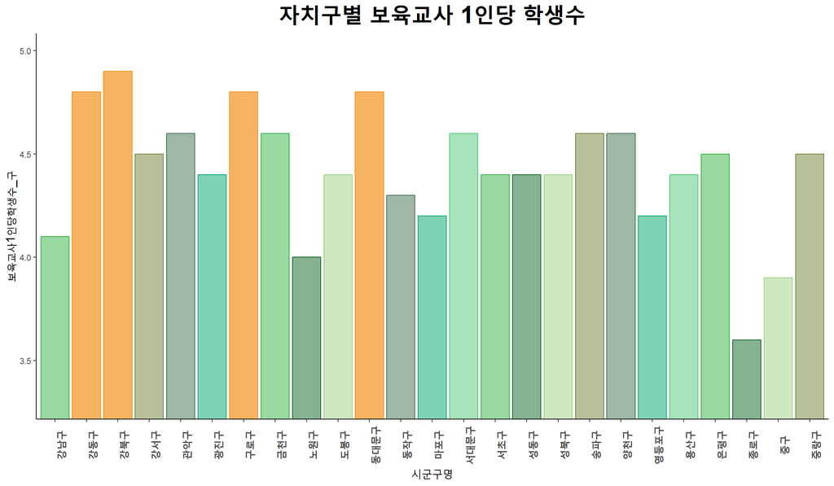

▲ 서울시 자치구별 보육교사 1인당 학생 수. 노란색으로 표시된 자치구는 4.7이상

#### 보육교사 1인당 학생 수가 많다는 것은 영유아 밀집도가 높고 보육서비스 이용 수요가 많다는 것을 의미한다. 따라서 다른 자치구에 비해서 상대적으로 높은 값을 가지는 강동구, 강북구, 구로구, 동대문구의 특성을 반영해 입지를 선정할 필요가 있어 보인다.

### 🏠 **자치구별 저소득/한부모 가구수**

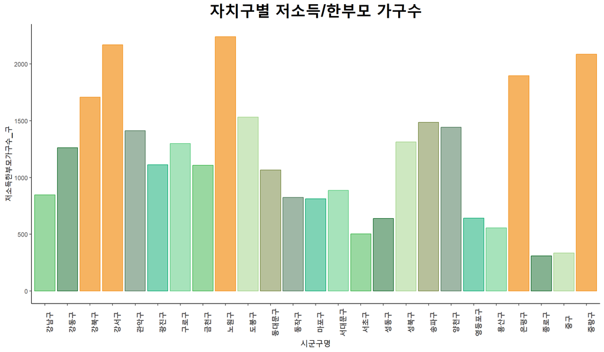

▲ 서울시 자치구별 저소득/한부모 가구수. 노란색으로 표시된 자치구는 가구수 1700이상.

#### 강북구, 강서구, 노원구, 은평구, 중랑구는 저소득/한부모 가구수가 가장 많은 상위 5개의 자치구이다. 저소득/한부모 가구수는 곧 높은 긴급보육의 수요와 직결될 수 있으리라고 추측할 수 있다. 따라서 이들 자치구의 특성을 반영해 입지를 선정할 필요가 있어 보인다.

### 📊 **365 열린 어린이집이 이미 입지한 자치구의 특징**

|  | 시군구명 | 평균보육실수 | 평균정원 | 평균현원 | 전체보육교사수 | 평균보육교사1인당학생수 | 평균소득 | 저소득한부모가구수 |
| --- | --- | --- | --- | --- | --- | --- | --- | --- |
| 1 | 강동구 | 4 | 35 | 16 | 2764 | 4.8 | 6056.72 | 1262 |
| 2 | 관악구 | 6 | 75 | 53 | 1885 | 4.6 | 5059.69 | 1412 |
| 3 | 노원구 | 7 | 95 | 83 | 2648 | 4 | 3808.2 | 2240 |
| 4 | 마포구 | 6 | 16 | 11 | 2078 | 4.2 | 5402.36 | 812 |
| 5 | 서초구 | 4 | 52 | 46 | 2170 | 4.4 | 10494.49 | 504 |
| 6 | 성북구 | 4 | 46 | 28 | 2100 | 4.4 | 3950.21 | 1313 |
| 7 | 양천구 | 5 | 64 | 38 | 2222 | 4.6 | 4539.07 | 1441 |
| 8 | 용산구 | 7 | 116 | 60 | 1146 | 4.4 | 5550.35 | 557 |
| 9 | 은평구 | 8 | 49 | 34 | 2531 | 4.5 | 4255.11 | 1897 |
| 10 | 종로구 | 6 | 49 | 30 | 987 | 3.6 | 5500.65 | 310 |

[output cut: 1 more lines]

▲ 365 열린 어린이집이 위치한 자치구의 통계량 (표)

### 📢 **365어린이집과 일반어린이집의 비교**

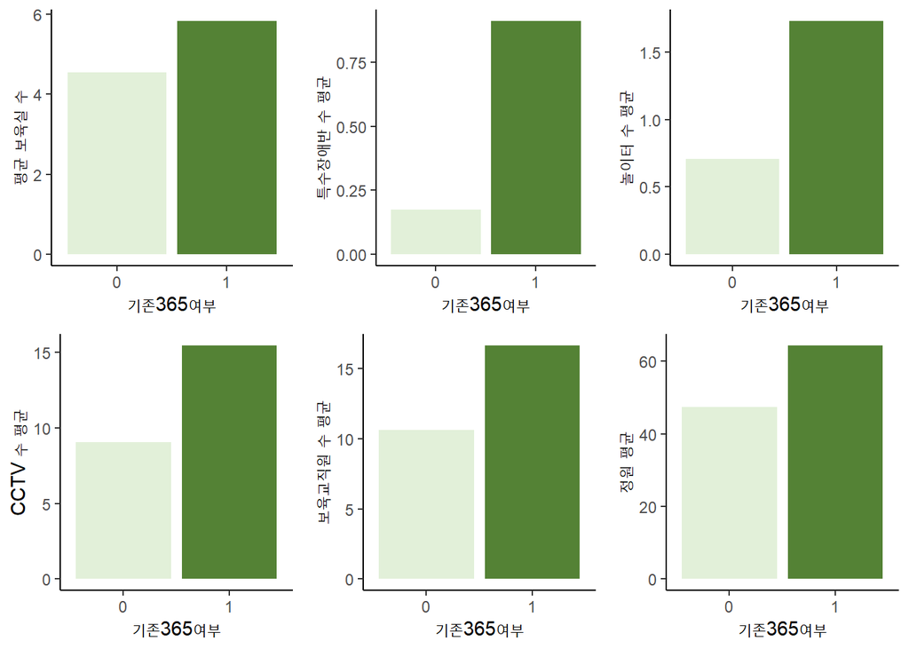

#### 보육실 수, 특수장애 반 수, 놀이터 수, CCTV 설치 수, 보육 교직원 수, 정원 등 어린이집 환경과 관련한 변수에서 기존 365어린이집이 긍정적인 방향으로 일반어린이집을 앞서고 있음을 파악할 수 있다.

# 🏆 **평가지표 개발**

### 📈 **로지스틱회귀분석**

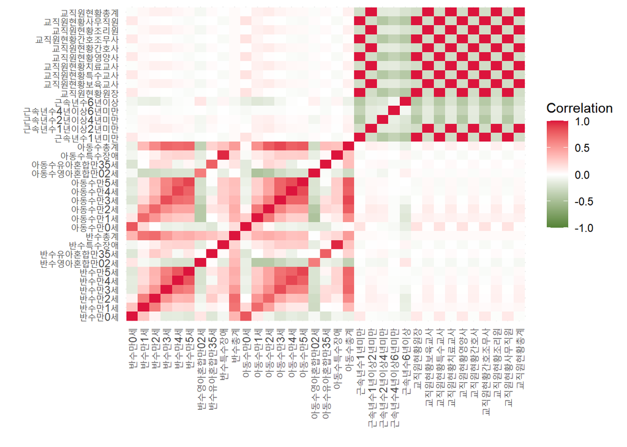

#### **5. 평가점수 조정** 평가지표의 값과 분산이 크기 때문에 직관적인 점수로 와닿지 않기 때문에 scaling을 진행해 환산점수를 계산한다.

# 📍 **365어린이집 입지선정**

#### 산출된 평가점수를 기준으로 내림차순 정렬하여 365어린이집 평가점수 순위를 파악한다.

|  | 어린이집명 | 시군구명 | 평가점수 | 순위 |
| --- | --- | --- | --- | --- |
| 1 | 구의미소어린이집 | 광진구 | 1000 점 | 1 위 |
| 2 | 아이꿈터어린이집 | 강북구 | 997.5 점 | 2 위 |
| 3 | 롯데호텔어린이집 | 송파구 | 997.1 점 | 3 위 |
| 4 | 아이꿈어린이집 | 성동구 | 995.8 점 | 4 위 |
| 5 | 늘사랑어린이집 | 도봉구 | 995.8 점 | 5 위 |
| 6 | 몬테소리동화나라어린이집 | 강서구 | 995.8 점 | 6 위 |
| 7 | 해맑은어린이집 | 마포구 | 995.7 점 | 7 위 |
| 8 | 반석어린이집 | 용산구 | 995.6 점 | 8 위 |
| 9 | 풍림어린이집 | 노원구 | 995.4 점 | 9 위 |
| 10 | 동광어린이집 | 노원구 | 995.4 점 | 10 위 |

[output cut: 4700 more lines]

▲ 365어린이집 적합성 평가 순위표

#### 이중 상위 10개의 어린이집을 선발한 후, EDA에서 파악한 바와 같이 자치구별 보육교사 1인당 학생수가 많은 강북구, 강동구, 구로구, 동대문구와, 자치구별 저소득/한부모 가구수가 많은 강북구, 강서구, 노원구, 은평구, 중랑구를 우선순위로 고려하여 순위를 재조정한다. 재조정 후 상위 5개의 어린이집을 최종 365어린이집 후보로 선정한다.

|  | 어린이집명 | 시군구명 | 평가점수 | 순위 |
| --- | --- | --- | --- | --- |
| 2 | 아이꿈터어린이집 | 강북구 | 997.5 점 | 1 위 |
| 6 | 몬테소리동화나라어린이집 | 강서구 | 995.8 점 | 2 위 |
| 9 | 풍림어린이집 | 노원구 | 995.4 점 | 3 위 |
| 10 | 동광어린이집 | 노원구 | 995.4 점 | 4 위 |
| 1 | 구의미소어린이집 | 광진구 | 1000 점 | 5 위 |

▲ 최종 365어린이집 입지선정 결과 5개소

#### 강북구에 속하는 아이꿈터어린이집 등이 상위 순위로 재조정된 결과를 확인할 수 있다.

# 👍 **기대 효과**

#### 365 열린 어린이집 입지선정 보조지표 제공 현재 목표는 자치구별 한 개의 365 열린 어린이집 배치지만 이후에도 여전히 확대 필요성이 있다. 따라서 본 분석에서 산출한 평가지표를 추가 입지선정의 보조지표로 활용할 수 있을 것이다. 아래는 기존의 365 어린이집 선정을 위한 평가항목이다.

| 구분 | 평가항목 | 심사내용 | 배점 |
| --- | --- | --- | --- |
| 정성평가 | 운영일반 | 전담반 운영 및 보육실 확보 여부 | 15 |
| 정성평가 | 운영일반 | 시설 등 보육환경 | 15 |
| 정성평가 | 운영일반 | 평가인증, 표창/시상 등 | 15 |
| 정성평가 | 접근성 | 대중교통, 자가용 이용 시 접근성 | 20 |
| 정성평가 | 접근성 | 지리적 위치 | 20 |
| 정량평가 | 취약보육 운영현황 | 심사내용 | 15 |

▲ 기존 365 열린 어린이집 선정기준일람

#### 현재의 일람에는 정성평가적인 요소와 단순한 위치정보를 활용하고 있다. 본 분석에서 개발한 평가지표를 활용한다면 기존에 고려하지 않던 자치구의 특성과, 가장 가까운 지하철역까지의 거리 등 공간관계적 요소를 반영하여 공간적 특성에 맞는 타당한 평가가 가능하다. 정성평가 요소를 계량화하여 365 열린 어린이집 선정에 객관적인 기준을 제시하였으며, 각 요인에 포함된 다양한 세부 요인들을 포괄적으로 평가했다는 점에서 지원자들이 선발결과를 쉽게 납득할 수 있다.

#### 자치구 간 육아 인프라 균형 확보 365열린 어린이집이 특히 필요한 자치구에 집중되어 육아 사각지대 문제를 완화하여 서울시의 틈새보육 서비스를 효과적으로 진행할 수 있다. 또한 자치구 간 균형 잡힌 육아 인프라 향상을 통해 영유아 공공보육 제도에 대한 사회적 인식을 제고할 수 있다.

[figure not shown]

#### 결혼감소이유 설문조사에서 상위를 차지한 대부분이 경기적, 인식적 요인으로 쉽게 해결하기 어렵지만, 출산/양육 지원 제도 부족 문제는 비교적 쉽게 해결이 가능하면서 서울시가 이미 시행 중인 사업으로 완화할 수 있는 문제이므로, 365어린이집의 적절한 선정과 운영을 통해 궁극적으로 조혼인율, 합계출산율 증가까지 기대할 수 있다.